# MAE augmentation - Additionnal descriptive analyses

Author

Mariam Rahali Masbouri, Khadija Rahali Masbouri, Laura Symul, Laura Vermeren

Published

July 2, 2026

```r
library(tidyverse)
library(magrittr)
library(gt)
library(patchwork)
library(grid)
library(gridExtra)
library(factoextra)
library(SummarizedExperiment)
library(tidySummarizedExperiment)
library(MultiAssayExperiment)

tmp <- fs::dir_map("R scripts/", source)
tmp <- fs::dir_map("../VIBRANT-99-utils/R/", source)
rm(tmp)
theme_set(theme_light())
```

```r
mae_files <-
  fs::dir_ls(
    get_03_output_dir(),
    regexp = "mae_full_05_.*\\.rds$"
  ) |>
  sort(decreasing = TRUE) |>
  magrittr::extract(1)

mae <- readRDS(mae_files)

rm(mae_files)
```

## Lab values

In this section, we document the lab values available in the `visits_crf_merged` table, and we create summary tables and visualizations to document the distribution of these lab values across visit codes and participants.

Specifically, four categories of lab values are considered: urinalysis results, pregnancy test results, vagina-related test results and STI lab results. We document these four categories of lab values in separate sections below.

### Unrinalysis results

The urinalysis results are available in `visits_crf_merged` table. Analyses were done using the Dipstick test, which provides semi-quantitative results for the following variables: glucose, bilirubin, ketone, blood, protein, specific gravity, pH, urobilinogen, nitrite and leukocyte values.

```r
urinalysis <-
  mae@metadata$visits_crfs_merged |>
  select(
    uid,
    urinalysis_not_applicable,
    bilirubin,
    ketone,
    blood,
    protein,
    specific_gravity_signs,
    specific_gravity_value,
    ph,
    urobilinogen,
    nitrite,
    leucocytes,
    glucose
  ) |>
  left_join(
    mae@colData |>
      as_tibble() |>
      select(uid, pid, study_day, visit_code, visit_type, randomized, site),
    by = join_by(uid)
  )
```

In the table below, we present the distribution of **glucose** values in the urinalysis data. We see that most of the samples have “Negative” values of glucose concentration in the urine, and the rest of the values are distributed across the different levels of glucose concentration in the urine.

```r
# summary table

urinalysis |>
  filter(!is.na(glucose)) |>
  group_by(glucose) |>
  summarise(
    n = n(),
    prop = n / nrow(urinalysis)
  ) |>
  arrange(desc(n)) |>
  gt(caption = "Distribution of glucose values in the urinalysis data") |>
  fmt_number(columns = prop, decimals = 4)
```

Distribution of glucose values in the urinalysis data

| Glucose | n | prop |
| --- | --- | --- |
| Negative | 899 | 0.1989 |
| Blank | 72 | 0.0159 |
| 4+ | 3 | 0.0007 |
| Trace | 3 | 0.0007 |
| 1+ | 1 | 0.0002 |
| 2+ | 1 | 0.0002 |
| 3+ | 1 | 0.0002 |

We document below the participants for which the glucose values are not negative, nor “blank”, by visit code.

```r
urinalysis |>
  filter(!is.na(glucose)) |>
  filter(glucose != "Negative" & glucose != "Blank") |>
  select(pid, study_day, visit_code, randomized, visit_type, site, glucose) |>
  arrange(pid, visit_code) |>
  gt(
    caption = "Participants with non-negative glucose values in the urinalysis data"
  )
```

Participants with non-negative glucose values in the urinalysis data

| pid | study_day | visit_code | randomized | visit_type | site | Glucose |
| --- | --- | --- | --- | --- | --- | --- |
| 068100026 | 0 | 1000 | TRUE | Clinic | MGH | 4+ |
| 068100026 | 7 | 1100 | TRUE | Clinic | MGH | 4+ |
| 068100026 | 35 | 1500 | TRUE | Clinic | MGH | 4+ |
| 068100026 | 76 | 2120 | TRUE | Clinic | MGH | 1+ |
| 068200048 | 0 | 0000 | FALSE | Clinic | CAP | Trace |
| 068200090 | 0 | 0000 | FALSE | Clinic | CAP | Trace |
| 068200108 | 0 | 0000 | FALSE | Clinic | CAP | 2+ |
| 068200241 | 0 | 0000 | FALSE | Clinic | CAP | 3+ |
| 068200399 | 7 | 1100 | TRUE | Clinic | CAP | Trace |

Only participant `068100026` has consistently high values of glucose concentration in the urine across multiple visits, with mostly values of “4+”. We also see that this participant is randomized, and has type II diabetes as pre-existing conditions. Participant `068200399` is also randomized, but has only a single “Trace” value of glucose concentration in the urine, and all other values are “Negative”. The rest of the participants with non-negative glucose are not randomized, and high urine concentration has only been measured as baseline for them.

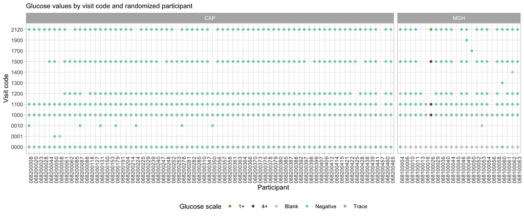

```r
# glucose

glucose_colors <- c(
  "Negative" = "#8ed0b4",
  "Trace" = "#8dc588",
  "1+" = "#79af59",
  "2+" = "#8f9243",
  "3+" = "#84753a",
  "4+" = "#74563e",
  Blank = "grey80"
)

urinalysis |>
  filter(!is.na(glucose)) |>
  filter(randomized) |>
  ggplot() +
  aes(y = visit_code, x = pid, color = glucose) +
  geom_point() +
  scale_color_manual(values = glucose_colors) +
  facet_wrap(~site, scales = "free_x", space = "free_x") +
  theme(
    legend.position = "bottom",
    axis.text.x = element_text(angle = 90, hjust = 1)
  ) +
  labs(
    subtitle = "Glucose values by visit code and randomized participant",
    y = "Visit code",
    x = "Participant",
    color = "Glucose scale"
  )
```

We present below the distribution of **bilirubin** values in the urinalysis data.

```r
# summary table

urinalysis |>
  filter(!is.na(bilirubin)) |>
  group_by(bilirubin) |>
  summarise(
    n = n(),
    prop = n / nrow(urinalysis |> filter(!is.na(bilirubin)))
  ) |>
  arrange(desc(n)) |>
  gt(caption = "Distribution of bilirubin values in the urinalysis data") |>
  fmt_number(columns = prop, decimals = 4)
```

Distribution of bilirubin values in the urinalysis data

| Bilirubin | n | prop |
| --- | --- | --- |
| Negative | 745 | 0.7602 |
| Blank | 156 | 0.1592 |
| 1+ | 62 | 0.0633 |
| Not applicable | 9 | 0.0092 |
| Not done | 5 | 0.0051 |
| 2+ | 2 | 0.0020 |
| Trace | 1 | 0.0010 |

Most samples seem to have “Negative” values of bilirubin, and the rest of the values are distributed across the different levels of bilirubin concentration in the urine.

We first document samples for which bilirubin values are “1+”, by visit code and participant, since it seems that a relatively high number of samples have this value.

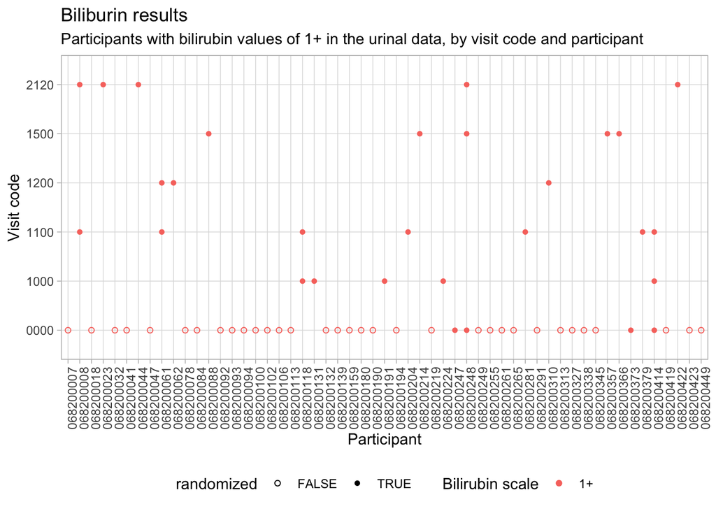

```r
urinalysis |>
  filter(!is.na(bilirubin)) |>
  filter(bilirubin == "1+") |>
  select(pid, study_day, visit_code, randomized, visit_type, site, bilirubin) |>
  ggplot() +
  aes(y = visit_code, x = pid, color = bilirubin, shape = randomized) +
  geom_point() +
  scale_shape_manual(values = c(1, 16)) +
  theme(legend.position = "bottom", axis.text.x = element_text(angle = 90)) +
  labs(
    title = "Biliburin results",
    subtitle = "Participants with bilirubin values of 1+ in the urinal data, by visit code and participant",
    y = "Visit code",
    x = "Participant",
    color = "Bilirubin scale"
  )
```

It looks like the “1+” values of bilirubin concentration in the urine are mostly measured at baseline, with mostly non-randomized participants, and only a few randomized participants with “1+” values of bilirubin concentration in the urine at baseline. We also see that there are some “1+” values of bilirubin concentration in the urine measured at later visit codes, and these are mostly from randomized participants.

We first document samples at visit 0000, which is the baseline visit code, for which bilirubin values are “1+”, from randomized participants.

```r
urinalysis |>
  filter(!is.na(bilirubin)) |>
  filter(bilirubin == "1+") |>
  filter(visit_code == "0000") |>
  filter(randomized) |>
  select(pid, study_day, visit_code, randomized, visit_type, site, bilirubin) |>
  arrange(pid) |>
  gt(
    caption = "Randomized participants with bilirubin values of 1+ at baseline in the urinalysis data"
  )
```

Randomized participants with bilirubin values of 1+ at baseline in the urinalysis data

| pid | study_day | visit_code | randomized | visit_type | site | Bilirubin |
| --- | --- | --- | --- | --- | --- | --- |
| 068200247 | -17 | 0000 | TRUE | Clinic | CAP | 1+ |
| 068200248 | -11 | 0000 | TRUE | Clinic | CAP | 1+ |
| 068200373 | -9 | 0000 | TRUE | Clinic | CAP | 1+ |
| 068200414 | -9 | 0000 | TRUE | Clinic | CAP | 1+ |

We now document below samples for which bilirubin values are either “Trace” or “+2”.

```r
urinalysis |>
  filter(!is.na(bilirubin)) |>
  filter(bilirubin == "Trace" | bilirubin == "2+") |>
  select(pid, study_day, visit_code, randomized, visit_type, site, bilirubin) |>
  arrange(pid, visit_code) |>
  gt(
    caption = "Participants with bilirubin values of Trace or 2+ in the urinalysis data"
  )
```

Participants with bilirubin values of Trace or 2+ in the urinalysis data

| pid | study_day | visit_code | randomized | visit_type | site | Bilirubin |
| --- | --- | --- | --- | --- | --- | --- |
| 068200129 | 0 | 0000 | FALSE | Clinic | CAP | 2+ |
| 068200329 | 0 | 0000 | FALSE | Clinic | CAP | Trace |
| 068200370 | 39 | 1500 | TRUE | Clinic | CAP | 2+ |

Among participants with a high value of bilirubin concentration in the urine, only participant `068200370` is randomized, and has value of “+2” at visit 1500.

We present below the distribution of bilirubin by visit code and participant, for randomized participants only.

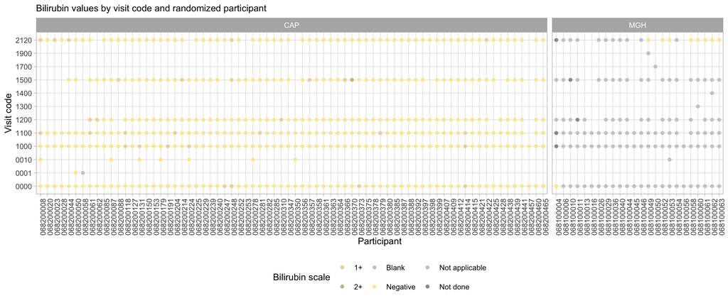

```r
# bilirubin

bilirubin_colors <- c(
  "Negative" = "#f8eaa3",
  "1+" = "#eed8a6",
  "2+" = "#c9c296",
  "3+" = "#c2ac94",
  "Blank" = "grey80",
  "Not applicable" = "grey80",
  "Not done" = "grey60"
)

urinalysis |>
  filter(!is.na(bilirubin)) |>
  filter(randomized) |>
  ggplot() +
  aes(y = visit_code, x = pid, color = bilirubin) +
  geom_point() +
  scale_color_manual(values = bilirubin_colors) +
  facet_wrap(~site, scales = "free_x", space = "free_x") +
  theme(
    legend.position = "bottom",
    axis.text.x = element_text(angle = 90, hjust = 1)
  ) +
  labs(
    subtitle = "Bilirubin values by visit code and randomized participant",
    y = "Visit code",
    x = "Participant",
    color = "Bilirubin scale"
  )
```

We document below the distribution of **ketone** values in the urinalysis data.

```r
# summary table

urinalysis |>
  filter(!is.na(ketone)) |>
  group_by(ketone) |>
  summarise(
    n = n(),
    prop = n / nrow(urinalysis |> filter(!is.na(ketone)))
  ) |>
  arrange(desc(n)) |>
  gt(caption = "Distribution of ketone values in the urinalysis data") |>
  fmt_number(columns = prop, decimals = 4)
```

Distribution of ketone values in the urinalysis data

| Ketone | n | prop |
| --- | --- | --- |
| Negative | 763 | 0.7786 |
| Trace | 118 | 0.1204 |
| Blank | 72 | 0.0735 |
| 1+ | 19 | 0.0194 |
| 2+ | 4 | 0.0041 |
| 4+ | 3 | 0.0031 |
| 3+ | 1 | 0.0010 |

Most samples seem to have “Negative” values of ketone, and the rest of the values are distributed across the different levels of ketone concentration in the urine. Several of them are “Trace” values of ketone concentration in the urine. We document below samples for which ketone concentration is higher or equal than “+1”, by visit code and participant.

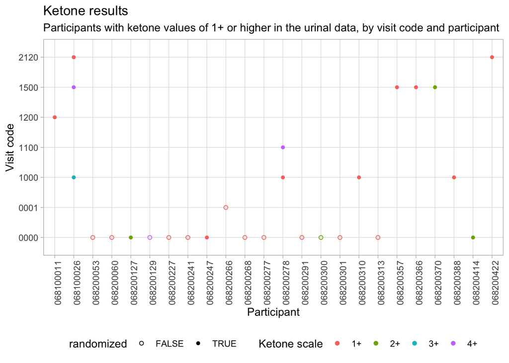

```r
urinalysis |>
  filter(!is.na(ketone)) |>
  filter(ketone == "1+" | ketone == "2+" | ketone == "3+" | ketone == "4+") |>
  select(pid, study_day, visit_code, randomized, visit_type, site, ketone) |>
  ggplot() +
  aes(y = visit_code, x = pid, color = ketone, shape = randomized) +
  geom_point() +
  scale_shape_manual(values = c(1, 16)) +
  theme(legend.position = "bottom", axis.text.x = element_text(angle = 90)) +
  labs(
    title = "Ketone results",
    subtitle = "Participants with ketone values of 1+ or higher in the urinal data, by visit code and participant",
    y = "Visit code",
    x = "Participant",
    color = "Ketone scale"
  )
```

We document in the table below the randomized participants with ketone values of “1+” or higher.

```r
urinalysis |>
  filter(!is.na(ketone)) |>
  filter(ketone == "1+" | ketone == "2+" | ketone == "3+" | ketone == "4+") |>
  filter(randomized) |>
  select(pid, study_day, visit_code, randomized, visit_type, site, ketone) |>
  arrange(pid) |>
  gt(
    caption = "Randomized participants with ketone values of 1+ or higher in the urinalysis data"
  )
```

Randomized participants with ketone values of 1+ or higher in the urinalysis data

| pid | study_day | visit_code | randomized | visit_type | site | Ketone |
| --- | --- | --- | --- | --- | --- | --- |
| 068100011 | 15 | 1200 | TRUE | Clinic | MGH | 1+ |
| 068100026 | 35 | 1500 | TRUE | Clinic | MGH | 4+ |
| 068100026 | 76 | 2120 | TRUE | Clinic | MGH | 1+ |
| 068100026 | 0 | 1000 | TRUE | Clinic | MGH | 3+ |
| 068200127 | -15 | 0000 | TRUE | Clinic | CAP | 2+ |
| 068200247 | -17 | 0000 | TRUE | Clinic | CAP | 1+ |
| 068200278 | 0 | 1000 | TRUE | Clinic | CAP | 1+ |
| 068200278 | 7 | 1100 | TRUE | Clinic | CAP | 4+ |
| 068200310 | 0 | 1000 | TRUE | Clinic | CAP | 1+ |
| 068200357 | 39 | 1500 | TRUE | Clinic | CAP | 1+ |
| 068200366 | 39 | 1500 | TRUE | Clinic | CAP | 1+ |
| 068200370 | 39 | 1500 | TRUE | Clinic | CAP | 2+ |
| 068200388 | 0 | 1000 | TRUE | Clinic | CAP | 1+ |
| 068200414 | -9 | 0000 | TRUE | Clinic | CAP | 2+ |
| 068200422 | 71 | 2120 | TRUE | Clinic | CAP | 1+ |

Participant `068100026` has several values of ketone concentration in the urine higher or equal than “1+”, across multiple visit codes, and mostly at later visit codes, which is consistent with its high values of glucose concentration in the urine. This participant is randomized, and has type II diabetes as pre-existing conditions. We also notice high concentration of ketone in the urine for participant `068200278`. Participant `068200370` has a single value of “2+” for ketone concentration in the urine at visit code 1500, which happens to be the same visit code at which this participant has a value of “+2” for bilirubin concentration in the urine.